# Selection of peptides for retention time tracking - Second iteration

Ozan Aygun

May 24th, 2017

# 1 Introduction and Summary

**The goal of this analysis is to obtain a list of consensus peptides that are consistently detected in our QC runs, with the ultimate purpose of developing quality standards to monitor LC retention time variations.**

**I parsed a list of 120 unique peptides based on the criteria we discussed in our meeting last week and your feedback after the first iteration. Briefly, these peptides are consistently identified across all the QC runs I described below. They span the entire retention time span, and wherever possible, the entire m/z span we observed across the retention time. They do not contain any missed cleavages, Met, Cys, N-terminal pyro-glutamine.**

**The resulting peptides can be used as one large list of 120 peptides, or can be tested as 3 seperate peptide lists, each containing 40 peptides, covering low, medium and high abundance domains of the dynamic range.**

# 2 Choosing the relevant QC directories for peptide selection

In order to generate the desired peptide list, we selected the following JurkatQC runs:

| File | MS.MSspectracollectedC | MS.MSspectravalidV | CollectionYieldV.C… | ValidationYieldV.F… | MedianSPI… | MeanPrecursorMassError.ppm. | Timespanmid90.matchedspectrainrun.min. | GradientShapemid90.matchedspectrainrun | MedianMS1peakwidthmid90.matchedspectra.sec. | MedianMS2filltimemid90.matchedspectra.msec. | DigestMissedCleavagestrypsin..DistinctpepsCS. | DistinctPepsCSTotal.number_of. | FDRSpectra… | number_ofSpectraFalse | instrument | paths |
| --- | --- | --- | --- | --- | --- | --- | --- | --- | --- | --- | --- | --- | --- | --- | --- | --- |
| GN20170519_CRH_JurkatQC_01 | 56756 | 37238 | 65.6 | 72.4 | 81.4 | 3.3 | 78 | 9987532 | 12 | 15 | 20.9 | 30701 | 0.76 | 141 | Galileo | //coston/msdatasm/JurkatQC//Galileo/2017Q2/20170522/qualityMetricsExport.1.ssv |
| GN20170516_CRH_JurkatQC_01 | 57074 | 37101 | 65.0 | 72.1 | 81.6 | 2.9 | 78 | 9986542 | 12 | 13 | 20.8 | 30380 | 0.79 | 146 | Galileo | //coston/msdatasm/JurkatQC//Galileo/2017Q2/20170519/qualityMetricsExport.1.ssv |
| GN20170515_CRH_JurkatQC_01 | 56358 | 37148 | 65.9 | 72.6 | 81.8 | 3.4 | 78 | 9986541 | 12 | 14 | 20.8 | 30504 | 0.82 | 152 | Galileo | //coston/msdatasm/JurkatQC//Galileo/2017Q2/20170516/qualityMetricsExport.1.ssv |
| H2A_20170522_LCT_Jurkat_01 | 54869 | 35595 | 64.9 | 71.3 | 79.9 | 4.0 | 78 | 8986531 | 12 | 30 | 27.5 | 29639 | 0.94 | 167 | Hubble2 | //coston/msdatasm/JurkatQC//Hubble2/2017Q2/20170522_PM/qualityMetricsExport.1.ssv |
| H2A_20170519_LCT_Jurkat_03 | 56840 | 37671 | 66.3 | 70.9 | 79.0 | 4.1 | 79 | 8997531 | 12 | 17 | 22.1 | 31485 | 0.91 | 172 | Hubble2 | //coston/msdatasm/JurkatQC//Hubble2/2017Q2/20170522_SF/qualityMetricsExport.1.ssv |
| H2A_20170519_LCT_Jurkat_0X | 55840 | 36951 | 66.2 | 70.4 | 79.8 | 2.6 | 79 | 9986531 | 12 | 19 | 22.3 | 31670 | 0.91 | 169 | Hubble2 | //coston/msdatasm/JurkatQC//Hubble2/2017Q2/20170520_SF/qualityMetricsExport.1.ssv |
| FB20170522_MSz_Jurkat_03 | 57461 | 34714 | 60.4 | 67.6 | 76.5 | 1.3 | 76 | 8898643 | 14 | 17 | 22.1 | 29654 | 0.72 | 125 | Franklin | //coston/msdatasm/JurkatQC//Franklin/2017Q2/20170524/qualityMetricsExport.1.ssv |
| FB20170522_MSz_Jurkat_01 | 58175 | 33289 | 57.2 | 64.4 | 75.6 | 2.4 | 77 | 8898743 | 15 | 16 | 22.6 | 28138 | 0.80 | 133 | Franklin | //coston/msdatasm/JurkatQC//Franklin/2017Q2/20170522/qualityMetricsExport.1.ssv |
| FB20170518_MM_Jurkat_QC_01 | 57354 | 35695 | 62.2 | 68.4 | 77.2 | 2.3 | 77 | 8899753 | 13 | 17 | 22.6 | 30064 | 0.80 | 143 | Franklin | //coston/msdatasm/JurkatQC//Franklin/2017Q2/20170519/qualityMetricsExport.1.ssv |
| YJ20170518_SV_Jurkat02 | 72826 | 41059 | 56.4 | 64.0 | 81.4 | 2.2 | 77 | 9998554 | 9 | 39 | 23.1 | 40101 | 0.83 | 171 | Yoda | //coston/msdatasm/JurkatQC//Yoda/2017Q2/YJ_TS20170518/qualityMetricsExport.1.ssv |
| BL20170519_FM_Jurkat_01 | 83805 | 44542 | 53.1 | 60.1 | 81.4 | 2.7 | 78 | 7987644 | 9 | 18 | 23.1 | 43470 | 0.63 | 140 | Beaker | //coston/msdatasm/JurkatQC//Beaker/2017Q2/20170523_LCT/qualityMetricsExport.1.ssv |

In addition we included 2 HeLa Thermo Standard Runs that are previously searched at:

- bennett:/msdataSM/Lauren/InstrumentEvaluation/LumosEvaluation_HeLaCurve
- bennett:/msdataSM/Lauren/Hubble2_HeLaCurve

Spectrum Mill protein-peptide report was prepared this file was obtained:

- coston:/JurkatQC/Galileo/2017Q2/20170501/proteinPeptideComparisonColumnsExport.S.1.ssv

In this report, we obtained **98624** unique peptides. **4198** of these peptides were identified in all QC runs.

# 3 Global cut offs

Before going into peptide selection, I applied several filters based on your feedback and suggestions.

## 3.1 Exclude peptides with missed cleavages

At this stage we filtered any peptide that contains **more than one K or R**, as this will indicate missed cleavages.

This reduced the peptide list to **3563** unique peptides without missed cleavages.

## 3.2 Exclude peptides with Met, Cys and N-terminal pyro glutamic acid

At this stage we filtered any peptide that contains **M, C or q (N-term)**.

This reduced the peptide list to **1920** unique peptides without missed cleavages, Met, Cys or N-terminal pyro glutamic acid.

## 3.3 Abundance (total intensity) cut off

In the first iteration, Karl suggested to incorporate a customized intensity cut off. This will involve eliminating all peptides that are >1/3 the abundance of the median of the 50 most abundant (**REMAINING**)peptides.

Here, you can view what happens when I apply this filter to the remaining peptides:

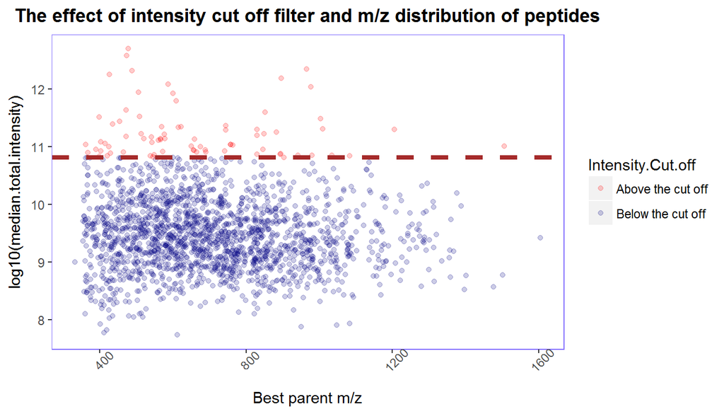

- We notice the non-uniform distribution of peptide abundance along the m/z axis.
- We also notice that such a cut off filters a small fraction of the peptides.

This further reduced the peptide list to **1844** unique peptides without missed cleavages, Met, Cys or N-terminal pyro glutamic acid and below the described abundance threshold.

# 4 Choosing a ‘score cut off’: relaxing the earlier score cut off

Karl suggested to apply a global score filter. In order to understand what would be a good score cutoff I looked the distribution of the **bestscores** for each peptide across all QC runs:

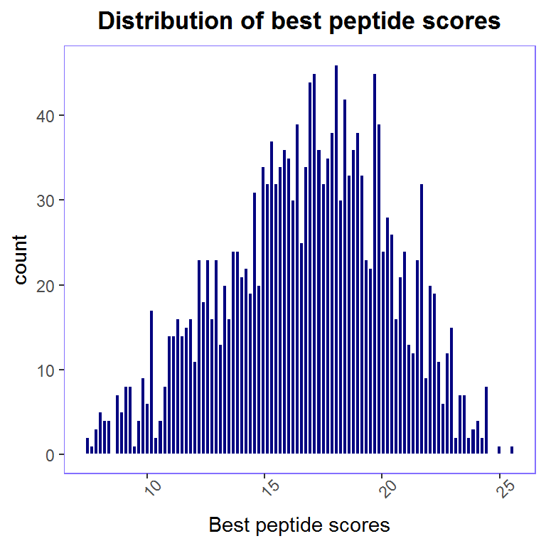

Scores have a near Gaussian distribution with a mean of **16.8**. Karl suggested that any score that is above 12 is deemed good. Therefore, I applied a score filtering for the peptides have scores that are equal and greater than 12.

This reduced the peptide list to **1653** unique peptides.

# 5 Distribution of retention time

It would be a good idea to look at the distribution of retention times of the remaining peptides to ensure the distribution is not too skewed:

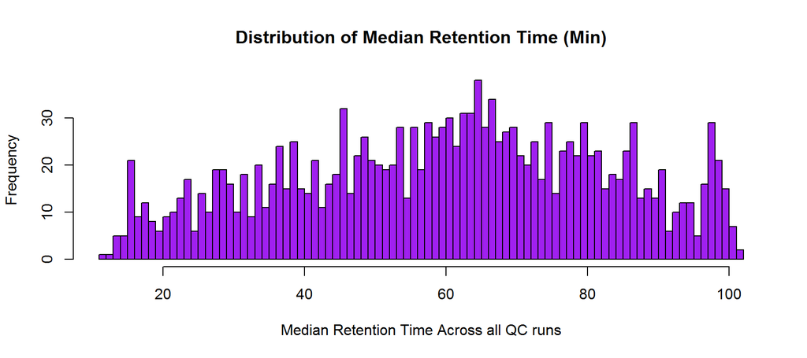

As we expected, we generally have more peptides in the mid-higher retention time range.

At this point, I simplified the data by using summary metrics that are robust to outliers.

Each peptide sequence will be associated with the following features:

- median retention time across all QC runs (Min)
- median total intensity across all QC runs
- best parent m/z

# 6 Distribution of m/z

This subset of peptides have near-Gaussian m/z distribution with a slight right skew:

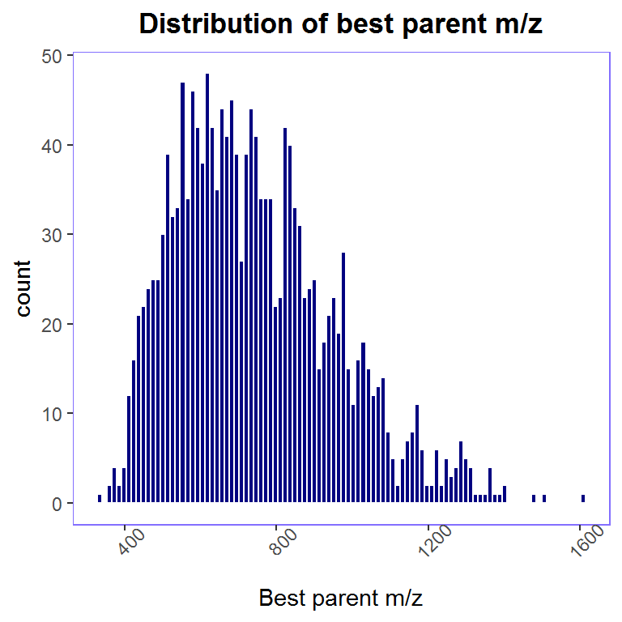

# 7 Partition data into 8 equal retention time bins

I partitioned the data based on 8 retention time bins as we discussed in our meeting:

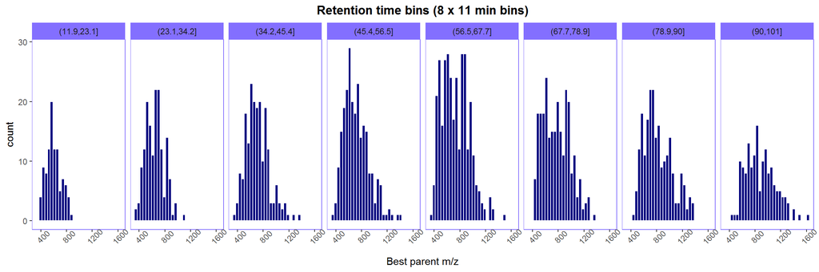

- We notice that the first 2 retention time bins (up to 35 minutes), we have limited representation of m/z, these domain mainly consists of peptides with m/z that are below the average m/z.
- Perhaps this is expected: highly charged peptides elute faster and are not retained in the column beyond 35 minutes.
- The rest of the retention time looks like a good representation of the overall m/z distribution.

# 8 Evaluating the intensities of the peptides

It is also important to check the intensity selection of the peptides in the retention bins:

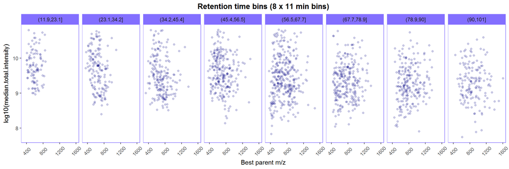

# 9 Assesing the representation of Histidine containing peptides

It appears that we have a good presence of Histidine containing peptides in the remaining subset:

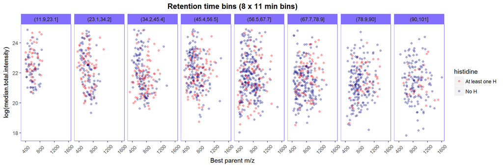

# 10 Modified algorihtm for the selection of peptides

In the second iteration, I modified the algorithm to prepare 3 different lists across the dynamic range (abundance bins).

**Note that in this version I choose the final peptide randomly, without biasing towards Histidine containing peptides. Even in this approach, we end up with fair amount of Histidine containing peptides in each retention time bin (see later).**

Peptides will be selected based on the following algorithm:

- Divide the retention time span into 8 equal time bins.
- For a given retention time bin:
  - Prepare 3 equal **intensity(abundance)** bins
    - For a given abundance bin:
    - Prepare 5 equal m/z bins
    - For a given m/z bin:
      - **Randomly** choose a peptide (do not bootstrap)

This provides us a final list of 120 peptides. We can use this list either as it is, or as 3 separate lists, each contain 40 peptides and represent ‘low’,‘medium’ or ‘high’ abundance ranges within each retention time bin.

# 11 Exploring the final selection of 120 peptides

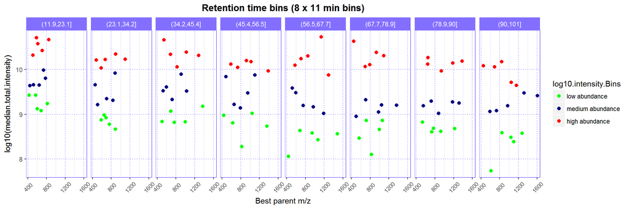

**Note that the low-medium-high intensity bins are all relative to a given retention time bin.**

# 12 Presence of histidine containing peptides in each retention time bin

In the last iteration, Karl suggested that it is sufficient to have at least one Histidine containing peptide in each retention time bin. Therefore, I checked the final list of peptides whether we can fulfill this need:

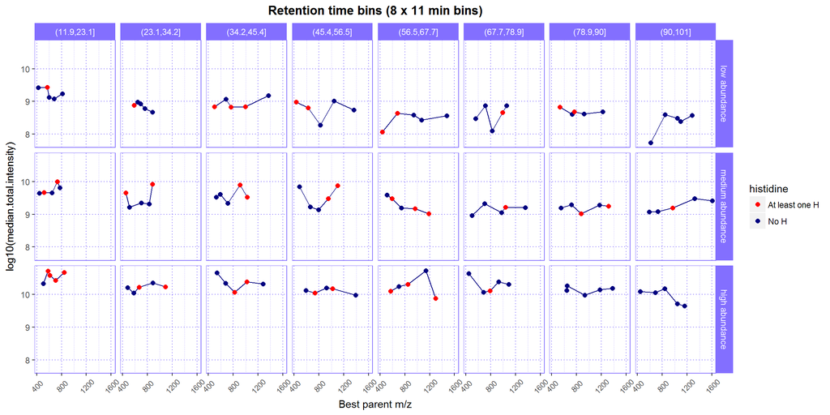

**Note that I just connected the peptide data points to make any trends in intensity fluctations more obvious.**

- If we use the list collapsed across the abundance bins, then there is at least one H containing peptide in each retention time bin.

These **120** distinct peptides come from **101** unique proteins (uniprot accession number).

# 13 Final list of the 120 selected peptides and their features

Therefore, we have selected a fair amount of peptides that are both representative (i.e: detected in all of the QC runs we profiled) as well as spanning retention time and m/z spans fairly well. I welcome your feedback on refining the selection of peptides as necessary.

The current selection of the peptides are:

| sequence | bestScore | median.retentionTimeMin | median.total.intensity | best_parent_m_over_z | accession_number | accession_numbers | median.retentionTime.Bins | histidine | log10.intensity.Bins | m_over_z_bins |
| --- | --- | --- | --- | --- | --- | --- | --- | --- | --- | --- |
| AQVIYTR | 12.38 | 18.37 | 2.68e+09 | 425.7436 | P62851 | P62851 | (11.9,23.1] | No H | low abundance | (425,505] |
| DAVTYTEHAK | 16.66 | 15.53 | 2.70e+09 | 567.7762 | P62805 | P62805 | (11.9,23.1] | At least one H | low abundance | (505,585] |
| QQSELQSQVR | 13.01 | 16.50 | 1.34e+09 | 601.8104 | Q14847 | Q14847-2 | (11.9,23.1] | No H | low abundance | (585,665] |
| AQAVSEDAGGNEGR | 16.15 | 13.87 | 1.22e+09 | 680.8103 | P55884-2 | P55884-2 | (11.9,23.1] | No H | low abundance | (665,744] |
| EGTGSTATSSSSTAGAAGK | 16.92 | 11.95 | 1.74e+09 | 814.3755 | B3KS98 | B3KS98\|O15372\|E5RH59\|E5RHC7 | (11.9,23.1] | No H | low abundance | (744,824] |
| ISDSEGFK | 14.00 | 17.02 | 4.43e+09 | 441.7142 | P23246 | P23246\|P23246-2 | (11.9,23.1] | No H | medium abundance | (405,496] |
| DHENIVIAK | 17.19 | 20.17 | 4.61e+09 | 519.7840 | P07237 | P07237\|H7BZ94\|F5H8J2 | (11.9,23.1] | At least one H | medium abundance | (496,587] |
| TIIQNPTDQQK | 15.20 | 22.90 | 4.54e+09 | 643.3425 | Q9UQ80 | Q9UQ80\|F8VR77 | (11.9,23.1] | No H | medium abundance | (587,677] |
| TATPQQAQEVHEK | 18.70 | 13.87 | 9.84e+09 | 733.8650 | P60174 | P60174\|P60174-1\|P60174-4 | (11.9,23.1] | At least one H | medium abundance | (677,768] |
| SVTEQGAELSNEER | 19.42 | 22.23 | 6.40e+09 | 774.8599 | P63104 | P63104 | (11.9,23.1] | No H | medium abundance | (768,859] |
| DYNVTANSK | 13.15 | 15.92 | 2.12e+10 | 506.2427 | P00338-3 | P00338-3\|P00338-2\|P00338-5 | (11.9,23.1] | No H | high abundance | (452,531] |
| LGIHEDSQNR | 18.17 | 15.03 | 5.16e+10 | 584.7911 | P07900-2 | P07900-2 | (11.9,23.1] | At least one H | high abundance | (531,610] |
| GHLENNPALEK | 20.55 | 15.70 | 3.81e+10 | 611.3162 | P05388 | P05388\|Q8NHW5\|F8VWS0\|P05388-2\|G3V210\|F8VRK7\|F8VQY6 | (11.9,23.1] | At least one H | high abundance | (610,690] |
| YHTINGHNAEVR | 17.93 | 15.00 | 2.68e+10 | 705.8464 | P22626 | P22626\|P22626-2 | (11.9,23.1] | At least one H | high abundance | (690,769] |
| HTGPNSPDTANDGFVR | 18.07 | 21.53 | 4.67e+10 | 842.8874 | G8JLB6 | G8JLB6\|P31943\|P55795\|E9PCY7\|D6RIH9 | (11.9,23.1] | At least one H | high abundance | (769,848] |
| ETHADLWPAK | 16.21 | 29.07 | 7.58e+08 | 584.2947 | P35606 | P35606\|P35606-2 | (23.1,34.2] | At least one H | low abundance | (529,603] |
| LEAEGVPEVSEK | 16.91 | 31.93 | 9.70e+08 | 643.8294 | O76003 | O76003 | (23.1,34.2] | No H | low abundance | (603,675] |
| TPQAPASANLVGPR | 17.96 | 32.63 | 8.46e+08 | 689.8773 | Q9UQ35 | Q9UQ35 | (23.1,34.2] | No H | low abundance | (675,748] |
| YDYEEVEAEGANK | 18.09 | 31.33 | 6.04e+08 | 758.8265 | P36871 | P36871-2\|P36871-3 | (23.1,34.2] | No H | low abundance | (748,821] |
| EQGQAPITPQQGQALAK | 16.84 | 31.00 | 4.72e+08 | 882.9664 | P84095 | P84095 | (23.1,34.2] | No H | low abundance | (821,894] |
| TLHPAVHAGILAR | 15.84 | 27.18 | 4.58e+09 | 452.6034 | P31939 | P31939\|P31939-2 | (23.1,34.2] | At least one H | medium abundance | (353,480] |
| AGIVTSLQAR | 13.88 | 33.63 | 1.65e+09 | 508.2999 | P49736 | P49736 | (23.1,34.2] | No H | medium abundance | (480,607] |
| FNEVAAQYSEDK | 14.50 | 27.38 | 2.24e+09 | 700.8218 | Q9Y237-2 | Q9Y237-2\|Q9Y237-3\|J3KMW3 | (23.1,34.2] | No H | medium abundance | (607,734] |
| GGGGGQDnGLEGLGNDSR | 17.83 | 27.38 | 2.08e+09 | 830.8624 | P08621 | P08621\|P08621-2\|P08621-4 | (23.1,34.2] | No H | medium abundance | (734,861] |
| VILGSEAAQQHPEEVR | 21.68 | 27.23 | 8.34e+09 | 881.9599 | Q9NY33 | G3V180\|G3V1D3\|Q9NY33\|Q9NY33-4\|Q9NY33-2 | (23.1,34.2] | At least one H | medium abundance | (861,988] |
| GLTSVINQK | 12.44 | 29.58 | 1.64e+10 | 480.2812 | P07195 | P07195 | (23.1,34.2] | No H | high abundance | (365,511] |
| GEFVTTVQQR | 14.53 | 27.02 | 1.10e+10 | 582.8056 | P40925-3 | P40925-3\|P40925-2\|B9A041\|B8ZZ51 | (23.1,34.2] | No H | high abundance | (511,657] |
| FYEEVHDLER | 20.18 | 33.02 | 1.68e+10 | 668.8137 | P55209 | P55209\|Q99733-2\|F5H4R6\|F8W0J6\|P55209-2\|B7Z9C2\|F8W543\|F8VV59\|B3KV44 | (23.1,34.2] | At least one H | high abundance | (657,802] |
| TDYNASVSVPDSSGPER | 19.41 | 33.13 | 2.24e+10 | 890.9038 | P61978-2 | P61978-2\|P61978-3\|Q5T6W5 | (23.1,34.2] | No H | high abundance | (802,948] |
| SLAGSSGPGASSGTSGDHGELVVR | 24.00 | 29.12 | 1.72e+10 | 1093.0289 | P29692 | E9PRY8\|P29692-2\|E9PMW7 | (23.1,34.2] | At least one H | high abundance | (948,1.09e+03] |

[output cut: 90 more lines]